# The Bootstrap

[figure not shown]

## The Bootstrap

A widely applicable and powerful statistical tool used to quantify the uncertainty of a given estimate or model.

### Basic Idea

With a dataset of \(n\) obs to which you've fit an estimate \(\hat{\theta}\).

1. Draw a bootstrap sample, of size \(n\) **with replacement**.
2. Fit your estimate, \(\hat{\theta}^*\) to the boostrap sample.
3. Repeat 1-2 many times and assess the variability in your estimate by looking at the *bootstrap distribution*.

## Ex: Simple Regression

Is there a relationship between fractionalization and growth?

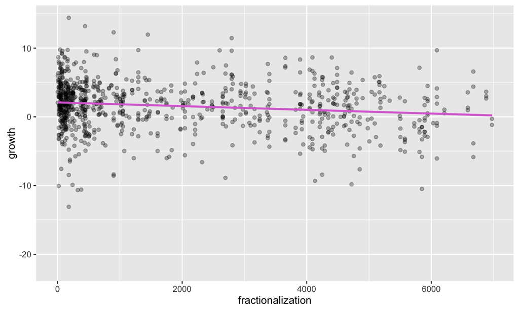

## Bootstrapping \(\hat{\beta}_1\)

```r
betas <- rep(NA, 5000)
for(i in 1:5000) {
  boot_ind <- sample(1:nrow(war), size = nrow(war), replace = TRUE)
  war_boot <- war[boot_ind, ]
  betas[i] <- coef(lm(growth ~ fractionalization, data = war_boot))[2]
}
```

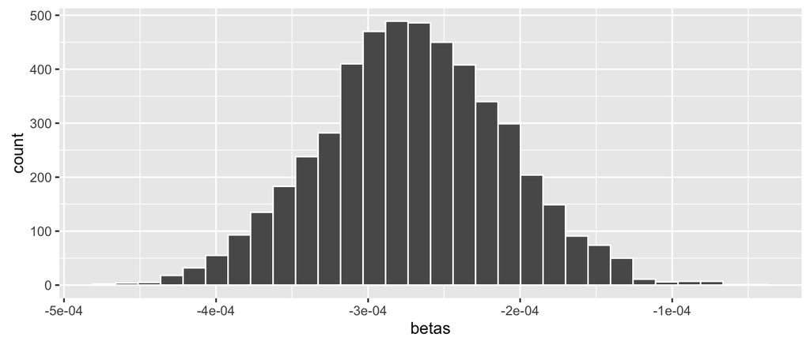

## Bootstrap distribution

```r
mean(betas)
```

```
## [1] -0.0002706865
```

```r
sd(betas)
```

```
## [1] 6.088038e-05
```

```r
summary(m1)$coef
```

```
##                        Estimate   Std. Error   t value     Pr(>|t|)
## (Intercept)        2.0964034623 1.592597e-01 13.163424 2.925458e-36
## fractionalization -0.0002704172 5.956005e-05 -4.540245 6.398626e-06
```

In this case, the bootstrap estimate of \(SE(\hat{\beta}_1)\) is quite similar to those from the t-distribution. Why?

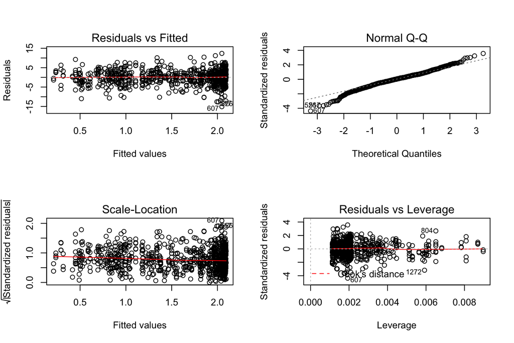

## A common argument

*Parametric methods have assumptions that often aren't reasonable, therefore the boostrap is preferable because it's assumption free.*

The bootstrap requires a sample that captures the important structure in the data. Difficult with small samples of skewed data.

But it sure is flexible . . .

Is there a relationship between fractionalization and growth in terms of the **correlation coefficient**?

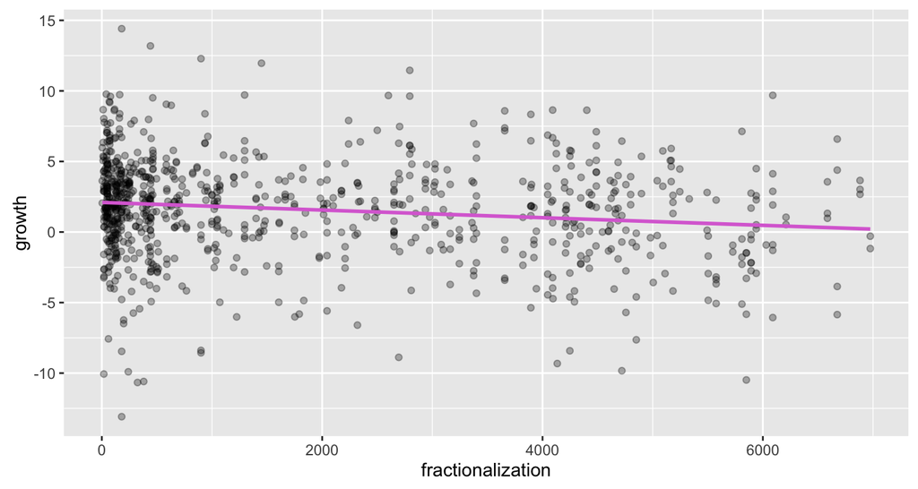

r = -0.151

## Bootstrapping \(r\)

```r
corrs <- rep(NA, 5000)
for(i in 1:5000) {
  boot_ind <- sample(1:nrow(war), size = nrow(war), replace = TRUE)
  war_boot <- war[boot_ind, ]
  corrs[i] <- cor(war_boot$fractionalization, war_boot$growth)
}
```

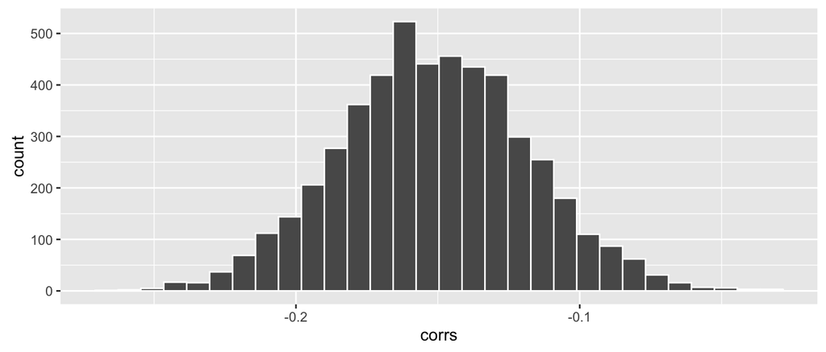

## Bootstrapping v. CV

Both are computationally intensive methods that involve sampling from your data set to learn more about your estimate/model.

### Cross-validation

Often used for *model assessment* and *model selection*.

- Partition data into test and train
- Fit model to train, predict on test
- Iterate though all possible *folds* (not for VS)
- Compute aggregate measure of predictive ability

### Bootstrapping

Often used for quantifying uncertainty

- Draw a bootstrap sample of size \(n\) from your data *with replacement*.
- Compute estimate of interest
- Consider distribution of bootstrap estimates over many samples